# Apropiación TIC del Valle del Cauca

__En proceso__

Este conjunto de datos recopila información sobre la participación ciudadana en procesos de apropiación de Tecnologías de la Información y las Comunicaciones (TIC), a través de programas financiados por la convocatoria DigiCampus (personas beneficiadas) y cursos cortos ofrecidos por la Secretaría de Tecnologías de la Información y las Comunicaciones (SETIC) del Valle del Cauca.

## Que es digicampus?

DigiCampus es un programa de formación impulsado por la Secretaría de Tecnologías de la Información y las Comunicaciones (SETIC) del Valle del Cauca. Su objetivo principal es fomentar la apropiación social de las TIC en la ciudadanía a través de cursos, talleres o programas educativos de corta duración, orientados al desarrollo de habilidades digitales básicas y avanzadas.

Este proyecto busca beneficiar a cerca de 30,000 jóvenes que hayan terminado recientemente sus estudios básicos y que deseen formarse tecnica, tecnologica o profesionalmente en alguno de los programas ofrecidos. El propósito es que, al finalizar, estos jóvenes sean capaces de encontrar trabajo en su lugar de residencia y, así, reducir la brecha de desempleo que afecta a la región.

Si bien el enfoque del programa esta en la formacion virtual tambien cuenta con las modalidades hibrida y presencial

## Objetivo general

Analizar la participación ciudadana en procesos de apropiación de Tecnologías de la Información y las Comunicaciones (TIC) en el Valle del Cauca, a través de los programas financiados por la convocatoria DigiCampus y los cursos ofrecidos por la Secretaría de Tecnologías de la Información y las Comunicaciones (SETIC), con el fin de identificar patrones de acceso, distribución territorial, equidad y efectividad en la ejecución de estas iniciativas.

## Objetivos Específicos

1. **Caracterizar la participación ciudadana** en términos de sexo, nivel académico, modalidad de formación y beneficios recibidos, para identificar los perfiles predominantes y las brechas existentes.
2. **Analizar la cobertura territorial** de los programas, identificando los municipios con mayor y menor participación.
3. **Evaluar el comportamiento temporal** de la participación, mediante el análisis de fechas de inicio o beneficio, con el fin de identificar tendencias y posibles estacionalidades.
4. **Identificar los programas, modalidades y entidades ejecutoras más relevantes**, según volumen de participación y tipo de beneficio recibido, para apoyar la toma de decisiones institucionales y mejorar el diseño de futuras estrategias de apropiación TIC.

```python
import pandas as pd
import seaborn as sns
import matplotlib.pyplot as plt
from functions import *
```

```python
df = pd.read_excel('Apropiacion_TIC.xlsx')
df.head()
```

|  | Codigo_dpto | Departamento | Cod_municipio | Municipio | Latitud | Longitud | Sexo | Fecha beneficio ó Inicio | Clasificacion Academica | Entidad Organización | Programa | Modalidad | Beneficio |
| --- | --- | --- | --- | --- | --- | --- | --- | --- | --- | --- | --- | --- | --- |
| 0 | 76 | Valle del Cauca | 76020 | ALCALA | 4.6739 | -75.7825 | F | 2024-06-15 | Profesional | Universidad Nacional Abierta y a Distancia | Administración en Salud | Híbrido | Incentivo completo |
| 1 | 76 | Valle del Cauca | 76020 | ALCALA | 4.6739 | -75.7825 | F | 2024-06-14 | Profesional | Universidad Nacional Abierta y a Distancia | Administración en Salud | Híbrido | Incentivo completo |
| 2 | 76 | Valle del Cauca | 76020 | ALCALA | 4.6739 | -75.7825 | F | 2024-06-14 | Profesional | Universidad Nacional Abierta y a Distancia | Administración en Salud | Híbrido | Incentivo completo |
| 3 | 76 | Valle del Cauca | 76020 | ALCALA | 4.6739 | -75.7825 | M | 2024-06-11 | Técnico | Fundación Politécnico Minuto de Dios | Técnico Profesional en Aseguramiento y Procesa... | Virtual | Incentivo completo |
| 4 | 76 | Valle del Cauca | 76020 | ALCALA | 4.6739 | -75.7825 | M | 2024-06-14 | Tecnología | Sena | Tecnología En Análisis Y Desarrollo De Software | Virtual | Incentivo completo |

## Exploracion de los datos

```python
df.shape
```

```
(4079, 13)
```

```python
df.info()
```

```
<class 'pandas.core.frame.DataFrame'>
RangeIndex: 4079 entries, 0 to 4078
Data columns (total 13 columns):
 #   Column                    Non-Null Count  Dtype
---  ------                    --------------  -----
 0   Codigo_dpto               4079 non-null   int64
 1   Departamento              4079 non-null   object
 2   Cod_municipio             4079 non-null   int64
 3   Municipio                 4079 non-null   object
 4   Latitud                   4079 non-null   float64
 5   Longitud                  4079 non-null   float64
 6   Sexo                      4079 non-null   object
 7   Fecha beneficio ó Inicio  4079 non-null   datetime64[ns]
 8   Clasificacion Academica   4079 non-null   object
 9   Entidad Organización      4079 non-null   object
 10  Programa                  4079 non-null   object
 11  Modalidad                 4079 non-null   object
 12  Beneficio                 4079 non-null   object
dtypes: datetime64[ns](1), float64(2), int64(2), object(8)
memory usage: 414.4+ KB
```

Correccion de tipo para el campo Fecha beneficio o Inicio

```python
df[A.Fecha_beneficio_ó_Inicio] = pd.to_datetime(df[A.Fecha_beneficio_ó_Inicio]).dt.floor('D')
```

```python
def resumen_nulos(df):
    total = df.isnull().sum()
    porcentaje = (total / len(df)) * 100
    return pd.DataFrame({'Valores Faltantes': total, 'Porcentaje': porcentaje})

resumen_nulos(df)
```

|  | Valores Faltantes | Porcentaje |
| --- | --- | --- |
| Codigo_dpto | 0 | 0.0 |
| Departamento | 0 | 0.0 |
| Cod_municipio | 0 | 0.0 |
| Municipio | 0 | 0.0 |
| Latitud | 0 | 0.0 |
| Longitud | 0 | 0.0 |
| Sexo | 0 | 0.0 |
| Fecha beneficio ó Inicio | 0 | 0.0 |
| Clasificacion Academica | 0 | 0.0 |
| Entidad Organización | 0 | 0.0 |
| Programa | 0 | 0.0 |
| Modalidad | 0 | 0.0 |
| Beneficio | 0 | 0.0 |

```python
duplicados = df.duplicated().sum()
duplicados
```

```
1405
```

Aunque el conteo de duplicados es alto no se procede a su eleiminacion para este analisis, pues estas coincidencias podrian corresponder a registros realizados por usuarios con identicos datos y al no contar con datos unicos del registrado no se puede definir duplicidad o coinciencia de registros y se asumiran como datos legitimos

```python
for col in df.select_dtypes(include='object'):
    print(f'\nColumna: {col}')
    print(df[col].value_counts().sort_values())
```

```
Columna: Departamento
Departamento
Valle del Cauca    4079
Name: count, dtype: int64

Columna: Municipio
Municipio
LA VICTORIA               3
EL DOVIO                  6
ARGELIA                   6
BOLIVAR                   6
EL CAIRO                  7
EL AGUILA                 7
OBANDO                    7
LA CUMBRE                 8
ULLOA                     8
ANSERMANUEVO              9
TRUJILLO                 11
VIJES                    11
RESTREPO                 12
SAN PEDRO                12
TORO                     12
BUGALAGRANDE             12
YOTOCO                   13
RIOFRIO                  15
SEVILLA                  16
ALCALA                   23
VERSALLES                25
GUACARI                  26
GINEBRA                  28
CALIMA                   30
CAICEDONIA               31
ANDALUCIA                36
CARTAGO                  38
ZARZAL                   38
GUADALAJARA DE BUGA      46
DAGUA                    51
ROLDANILLO               52
LA UNION                 57
EL CERRITO               67
```

[output cut: 98 more lines]

```
Administración en Salud                                                    341
Name: count, dtype: int64

Columna: Modalidad
Modalidad
Presencial     152
Híbrido        632
Virtual       3295
Name: count, dtype: int64

Columna: Beneficio
Beneficio
Incentivo completo    1920
Incentivo parcial     2159
Name: count, dtype: int64
```

Se corrigen terminos mal escritos

```python
correcciones = {
    "Ingenería de Sistemas": "Ingeniería de Sistemas",
    "Ingenería electrónica": "Ingeniería Electrónica",
    "Ingeniería industrial": "Ingeniería Industrial",
    "Ingeniería Industrial.": "Ingeniería Industrial",
    "Tecnología en Regencia de Framacia": "Tecnología en Regencia de Farmacia",
    "Ingeniería de Electrónica": "Ingeniería Electrónica",
}

df[A.Programa] = df[A.Programa].replace(correcciones)
```

```python
df[A.Programa] = df[A.Programa].replace({"Seguridad y Salud en el Trabajo Virtual":"Seguridad y Salud en el Trabajo"})
```

```python
df[A.Municipio] = df[A.Municipio].replace({"BUGALAGRANDE":"BUGA LA GRANDE"})
```

Considerando que todos los datos corresponden al departamento del **Valle del Cauca** con codigo de departamento **76** se procede a eliminar esta columna Al igual que la columna **Codigo_dpto**. Tambien se eliminan las columnas de **latitud** y **longitud** pues no son de valor para este analisis

```python
dff = df.drop(columns=[A.Departamento,A.Codigo_dpto, A.Latitud, A.Longitud])
dff
```

|  | Cod_municipio | Municipio | Sexo | Fecha beneficio ó Inicio | Clasificacion Academica | Entidad Organización | Programa | Modalidad | Beneficio |
| --- | --- | --- | --- | --- | --- | --- | --- | --- | --- |
| 0 | 76020 | ALCALA | F | 2024-06-15 | Profesional | Universidad Nacional Abierta y a Distancia | Administración en Salud | Híbrido | Incentivo completo |
| 1 | 76020 | ALCALA | F | 2024-06-14 | Profesional | Universidad Nacional Abierta y a Distancia | Administración en Salud | Híbrido | Incentivo completo |
| 2 | 76020 | ALCALA | F | 2024-06-14 | Profesional | Universidad Nacional Abierta y a Distancia | Administración en Salud | Híbrido | Incentivo completo |
| 3 | 76020 | ALCALA | M | 2024-06-11 | Técnico | Fundación Politécnico Minuto de Dios | Técnico Profesional en Aseguramiento y Procesa... | Virtual | Incentivo completo |
| 4 | 76020 | ALCALA | M | 2024-06-14 | Tecnología | Sena | Tecnología En Análisis Y Desarrollo De Software | Virtual | Incentivo completo |
| ... | ... | ... | ... | ... | ... | ... | ... | ... | ... |
| 4074 | 76895 | ZARZAL | M | 2024-12-09 | Tecnología | Universidad Nacional Abierta y a Distancia | Tecnología en Gestión de Transportes | Virtual | Incentivo completo |
| 4075 | 76895 | ZARZAL | F | 2024-12-03 | Profesional | Universidad Santiago de Cali | Derecho | Virtual | Incentivo completo |
| 4076 | 76895 | ZARZAL | M | 2024-12-19 | Profesional | Universidad Cooperativa de Colombia | Ingeniería de Sistemas | Híbrido | Incentivo completo |
| 4077 | 76895 | ZARZAL | F | 2024-12-12 | Tecnología | Universidad Nacional Abierta y a Distancia | Tecnología en Producción Agrícola | Virtual | Incentivo parcial |
| 4078 | 76895 | ZARZAL | M | 2024-12-13 | Profesional | Universidad Nacional Abierta y a Distancia | Ingeniería de Sistemas | Virtual | Incentivo completo |

4079 rows × 9 columns

Clasificando cada institucion por publica o privada

```python
# Diccionario de clasificación
clasificacion = {
    'Universidad Nacional Abierta y a Distancia': 'Pública',
    'Fundación Politécnico Minuto de Dios': 'Privada',
    'Sena': 'Pública',
    'Universidad Santiago de Cali': 'Privada',
    'Universidad del Quindío': 'Pública',
    'Universidad Autónoma de Occidente': 'Privada',
    'Institución Universitaria Antonio José Camacho': 'Pública',
    'Gobernacion del Valle del Cauca': 'Pública',
    'Corporación Universitaria Minuto de Dios': 'Privada',
    'Universidad Cooperativa de Colombia': 'Privada'
}



# Asignar tipo (Pública o Privada)
dff['Tipo'] = dff[A.Entidad_Organización].map(clasificacion)
```

### Periodo de fechas

El set de datos abarca un perido de 6 meses y medio

```python
diff = dff[A.Fecha_beneficio_ó_Inicio].max() - dff[A.Fecha_beneficio_ó_Inicio].min()
diff.days/30
```

```
6.566666666666666
```

```python
dff[A.Fecha_beneficio_ó_Inicio].describe()
```

```
count                             4079
mean     2024-09-07 04:50:11.326305536
min                2024-06-08 00:00:00
25%                2024-06-14 00:00:00
50%                2024-06-17 00:00:00
75%                2024-12-10 00:00:00
max                2024-12-22 00:00:00
Name: Fecha beneficio ó Inicio, dtype: object
```

```python
dff.describe(include=['object'])
```

|  | Municipio | Sexo | Clasificacion Academica | Entidad Organización | Programa | Modalidad | Beneficio |
| --- | --- | --- | --- | --- | --- | --- | --- |
| count | 4079 | 4079 | 4079 | 4079 | 4079 | 4079 | 4079 |
| unique | 42 | 3 | 4 | 10 | 53 | 3 | 2 |
| top | CALI | F | Profesional | Universidad Autónoma de Occidente | Ingeniería de Sistemas | Virtual | Incentivo parcial |
| freq | 1973 | 2238 | 3295 | 1354 | 499 | 3295 | 2159 |

- Este dataset contempla un total de **4079** registros de beneficiarios con informacion general
- Abarca un total de 42 municipios del departamento el **Valle del Cauca**
- La plataforma oficial de Dicampus señala que se ofrecen 47 programas de formacion. Pero a este punto se han agrupado algunos de ellos al ser la misma inea de formacion
- El set de datos abarca un periodo de 6 meses 2024-06-08 - 2024-12-22

```python
per_beneficiarios = (dff[A.Municipio].value_counts().max() / len(dff) )* 100
salida(f'**Cali** presenta el mayor numero de beneficiarios con el **{per_beneficiarios}%**')
```

**Cali** presenta el mayor numero de beneficiarios con el **48.3696984555038%**

```python
per_ciclos = (dff[A.Clasificacion_Academica].value_counts().max() / len(dff) )* 100
salida(f'cerca del **{per_ciclos}%** de beneficiarios se encuentran en ciclos **profesionales**')
```

cerca del **80.77960284383427%** de beneficiarios se encuentran en ciclos **profesionales**

```python
per_genero = (dff[A.Sexo].value_counts().max() / len(dff) )* 100
salida(f'El **{per_genero}%** de los beneficiarios son **mujeres**')
```

El **54.86638882078941%** de los beneficiarios son **mujeres**

```python
per_beneficio = (dff[A.Beneficio].value_counts().min() / len(dff) )* 100
salida(f'Solo el **{per_beneficio}%** de los beneficiarios cuentan con **financiacion completa**')
```

Solo el **47.07036038244668%** de los beneficiarios cuentan con **financiacion completa**

### Frecuencias

```python
dff.head(1)
```

|  | Cod_municipio | Municipio | Sexo | Fecha beneficio ó Inicio | Clasificacion Academica | Entidad Organización | Programa | Modalidad | Beneficio |
| --- | --- | --- | --- | --- | --- | --- | --- | --- | --- |
| 0 | 76020 | ALCALA | F | 2024-06-15 | Profesional | Universidad Nacional Abierta y a Distancia | Administración en Salud | Híbrido | Incentivo completo |

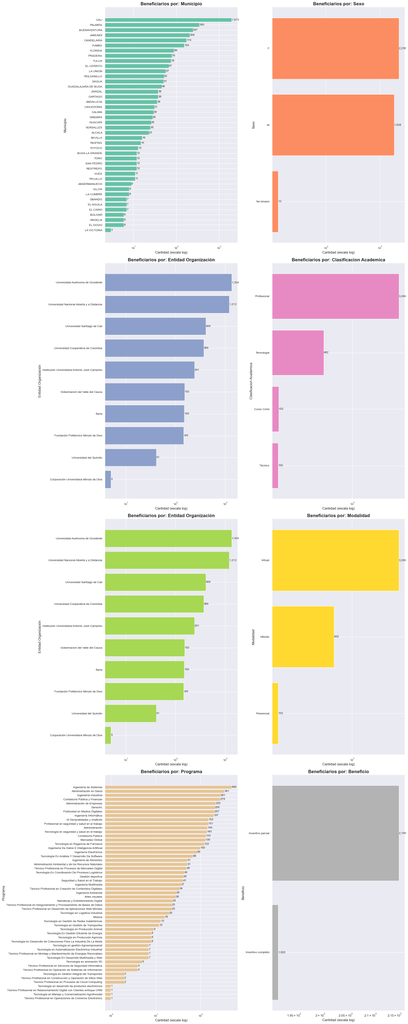

```python
# Estilo general más estético
sns.set_theme(style="darkgrid")  # o 'darkgrid', 'ticks'

columns_a = [
    A.Municipio, A.Sexo, A.Entidad_Organización, A.Clasificacion_Academica,
    A.Entidad_Organización, A.Modalidad, A.Programa, A.Beneficio
]

fig, ax = plt.subplots(4, 2, figsize=(20, 50))
ax = ax.flatten()

# Paleta de colores alternativos para visualmente distinguir
colors = sns.color_palette("Set2", len(columns_a))

for i, (axis, col) in enumerate(zip(ax, columns_a)):
    conteo = dff[col].value_counts().sort_values()

    axis.barh(conteo.index, conteo.values, color=colors[i])
    axis.set_xscale('log')

    # Título claro y con mejor tipografía
    axis.set_title(f'Beneficiarios por: {col}', fontsize=16, fontweight='bold')

    # Ejes más grandes y legibles
    axis.set_xlabel('Cantidad (escala log)', fontsize=12)
    axis.set_ylabel(col, fontsize=12)

    # Mostrar valores en el gráfico
    for y, x in enumerate(conteo.values):
        axis.text(x, y, f'{x:,}', va='center', ha='left', fontsize=10)

    # Ajustar tamaño de los ticks
    axis.tick_params(axis='both', labelsize=10)

# Espaciado automático para evitar que se encimen
plt.tight_layout()
```

### Analisis temporal

```python
dff['mes'] = dff[A.Fecha_beneficio_ó_Inicio].dt.month
```

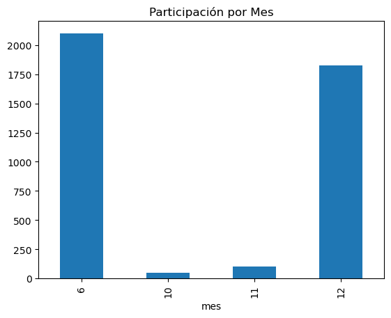

```python
participacion_mensual = dff['mes'].value_counts().sort_index()

participacion_mensual.plot(kind='bar', title='Participación por Mes')
```

Que la mayor participacion del programa sea en los meses de unio y diciembre podria estar relacionada con las fehcas de receso escolar de mitad de año y fin de año, esto considerando que en los requisitos solo se requiere haber presentado el icfes mas no se solicita al postulante haber recibido su carton de bachiller

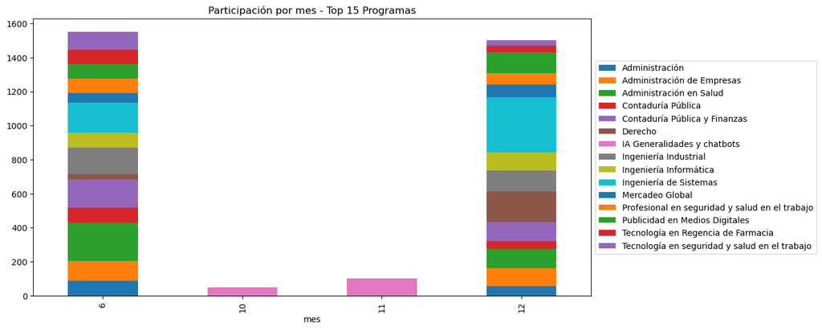

```python
top_programas = dff[A.Programa].value_counts().nlargest(15).index
df_top = dff[dff[A.Programa].isin(top_programas)]

ax = df_top.groupby(['mes', A.Programa]).size().unstack().plot(
    kind='bar', stacked=True, figsize=(12, 6),
    title='Participación por mes - Top 15 Programas'
)


ax.legend(loc='center left',bbox_to_anchor=(1.0, 0.5))
```

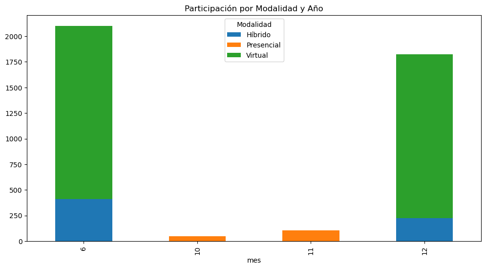

```python
dff.groupby(['mes', A.Modalidad]).size().unstack().plot(kind='bar', stacked=True, figsize=(12, 6), title='Participación por Modalidad y Año')
```

La poca participacion en los meses de octubre y noviembre podria atribuirse a dos causas principales

1. Solo se ofrecio el programa 'IA Generalidades y chatbots'
2. El unico programa ofrecido fue solo en modalidad 'Presencial'

```python
dff = pd.read_csv('copia.csv')
```

### Segmentaciones

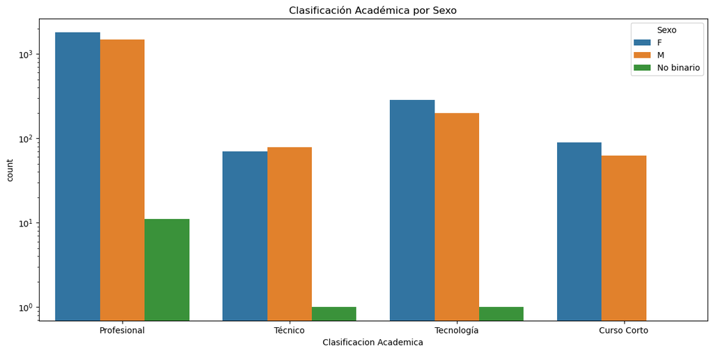

```python
plt.figure(figsize=(12, 6))
sns.countplot(data=dff, x=A.Clasificacion_Academica, hue=A.Sexo)
plt.yscale('log')
plt.title('Clasificación Académica por Sexo')
plt.legend(title='Sexo')
plt.tight_layout()
```

El genero **Femenino** lidera con el mayor numero de beneficiarios en todos los tipos de formacion a excepcion de la modaldiad Tecnica donde su diferencia con el genero **Masculino** es poco significativa

El genero **No Binario** representa una minoria en comparacion a los otros dos generos disponibles

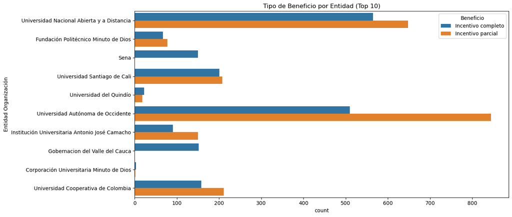

```python
plt.figure(figsize=(14, 6))
sns.countplot(data=dff, y=A.Entidad_Organización, hue=A.Beneficio)
plt.title('Tipo de Beneficio por Entidad (Top 10)')
plt.legend(title='Beneficio')
plt.tight_layout()
```

Acorde a su modelo de negocios las entidades privadas presentan una amplia diferencia de en tipo de incentivos ofrecido,

```python
tabla_pct = dff.groupby(['Tipo', A.Beneficio]).size().reset_index(name='conteo')

# Calcular porcentajes dentro de cada tipo de entidad
tabla_pct['porcentaje'] = tabla_pct.groupby('Tipo')['conteo'].transform(lambda x: (x / x.sum()) * 100)
```

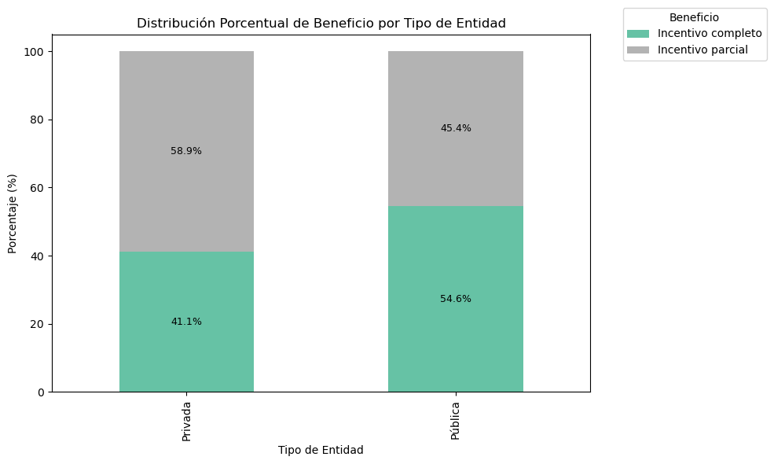

```python
# Crear gráfico de barras apiladas a partir de la tabla de porcentajes
pivot_pct = tabla_pct.pivot(index='Tipo', columns=A.Beneficio, values='porcentaje')
ax = pivot_pct.plot(kind='bar', stacked=True, figsize=(10, 6), colormap='Set2')

# Añadir etiquetas de porcentaje en cada segmento de barra
for container in ax.containers:
    ax.bar_label(container, fmt='%.1f%%', label_type='center', fontsize=9, color='black')



plt.title('Distribución Porcentual de Beneficio por Tipo de Entidad')
plt.xlabel('Tipo de Entidad')
plt.ylabel('Porcentaje (%)')
plt.legend(title='Beneficio', bbox_to_anchor=(1.05, 1), loc='center left')
plt.tight_layout()
plt.show()
```

```python
dff['Tipo'].value_counts()
```

```
Tipo
Privada    2282
Pública    1797
Name: count, dtype: int64
```

### Resolucion de objetivos especificos

Primero:

**Caracterizar la participación ciudadana** en términos de sexo, nivel académico, modalidad de formación y beneficios recibidos, para identificar los perfiles predominantes y las brechas existentes.

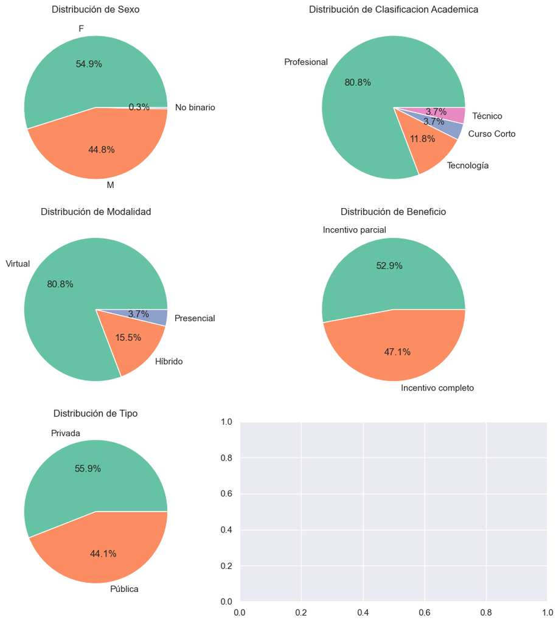

```python
sns.set_theme(style="darkgrid")  # o 'darkgrid', 'ticks'

pie_columns = [A.Sexo, A.Clasificacion_Academica, A.Modalidad, A.Beneficio,'Tipo']

fig, ax = plt.subplots(3, 2, figsize=(11, 11))
ax = ax.flatten()

# Paleta de colores alternativos para visualmente distinguir
colors = sns.color_palette("Set2", len(pie_columns))

for i, (axis, col) in enumerate(zip(ax, pie_columns)):

    counts = dff[col].value_counts()

    # Crear pie chart
    axis.pie(counts.values, labels=counts.index, autopct='%1.1f%%', colors=colors)
    axis.set_title(f"Distribución de {col}")




plt.tight_layout()
```

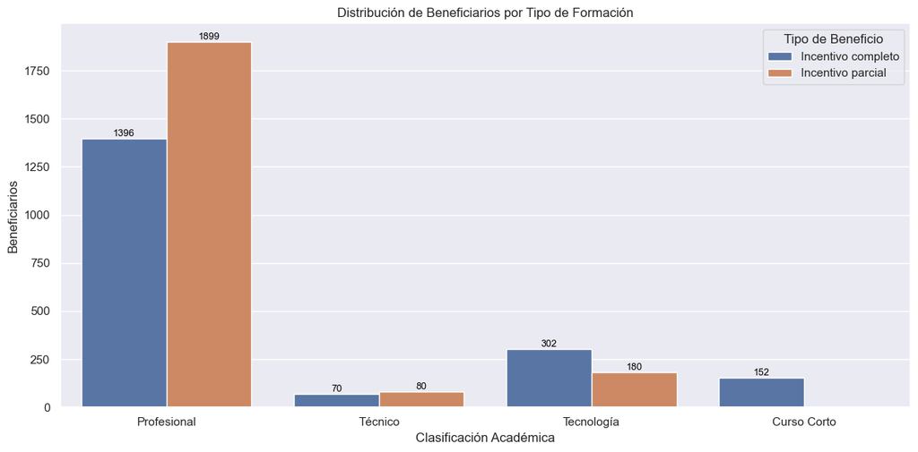

```python
plt.figure(figsize=(12, 6))
ax= sns.countplot(data=dff, x=A.Clasificacion_Academica, hue=A.Beneficio)
plt.title('Distribución de Beneficiarios por Tipo de Formación')
plt.xlabel('Clasificación Académica')
plt.ylabel('Beneficiarios')
plt.legend(title='Tipo de Beneficio')
plt.tight_layout()

for container in ax.containers:
    ax.bar_label(container, label_type='edge', fontsize=9, color='black')
```

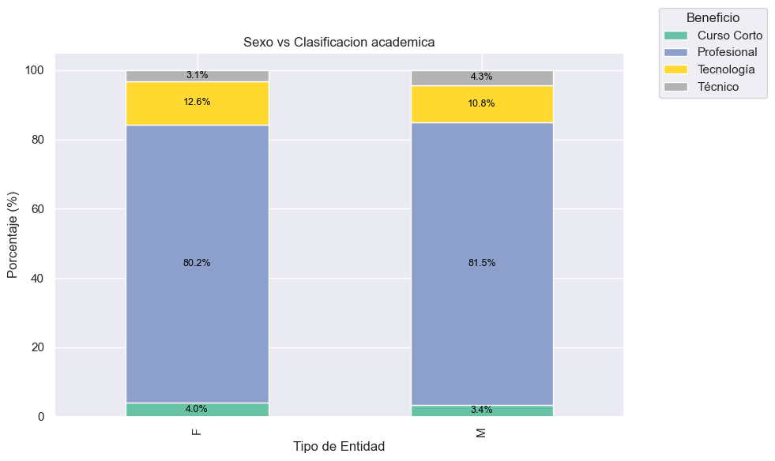

```python
tabla_sex_clas = dff[dff[A.Sexo] != 'No binario'].groupby([A.Sexo, A.Clasificacion_Academica]).size().reset_index(name='conteo')

# Calcular porcentajes dentro de cada tipo de entidad
tabla_sex_clas['porcentaje'] = tabla_sex_clas.groupby(A.Sexo)['conteo'].transform(lambda x: (x / x.sum()) * 100)


pivot_pct = tabla_sex_clas.pivot(index=A.Sexo, columns=A.Clasificacion_Academica, values='porcentaje')
ax = pivot_pct.plot(kind='bar', stacked=True, figsize=(10, 6), colormap='Set2')

# Añadir etiquetas de porcentaje en cada segmento de barra
for container in ax.containers:
    ax.bar_label(container, fmt='%.1f%%', label_type='center', fontsize=9, color='black')



plt.title('Sexo vs Clasificacion academica')
plt.xlabel('Tipo de Entidad')
plt.ylabel('Porcentaje (%)')
plt.legend(title='Beneficio', bbox_to_anchor=(1.05, 1), loc='center left')
plt.tight_layout()
plt.show()
```

[figure not shown]

```python
tabla_sex_clas = dff[dff[A.Sexo] != 'No binario'].groupby([A.Sexo, A.Modalidad]).size().reset_index(name='conteo')

# Calcular porcentajes dentro de cada tipo de entidad
tabla_sex_clas['porcentaje'] = tabla_sex_clas.groupby(A.Sexo)['conteo'].transform(lambda x: (x / x.sum()) * 100)


pivot_pct = tabla_sex_clas.pivot(index=A.Sexo, columns=A.Modalidad, values='porcentaje')
ax = pivot_pct.plot(kind='bar', stacked=True, figsize=(10, 6), colormap='Set2')

# Añadir etiquetas de porcentaje en cada segmento de barra
for container in ax.containers:
    ax.bar_label(container, fmt='%.1f%%', label_type='center', fontsize=9, color='black')



plt.title('Distribución Porcentual de Beneficio por Tipo de Entidad')
plt.xlabel('Tipo de Entidad')
plt.ylabel('Porcentaje (%)')
plt.legend(title='Beneficio', bbox_to_anchor=(1.05, 1), loc='center left')
plt.tight_layout()
plt.show()
```

```python
tabla_sex_clas = dff[dff[A.Sexo] != 'No binario'].groupby([A.Sexo, A.Beneficio]).size().reset_index(name='conteo')

# Calcular porcentajes dentro de cada tipo de entidad
tabla_sex_clas['porcentaje'] = tabla_sex_clas.groupby(A.Sexo)['conteo'].transform(lambda x: (x / x.sum()) * 100)


pivot_pct = tabla_sex_clas.pivot(index=A.Sexo, columns=A.Beneficio, values='porcentaje')
ax = pivot_pct.plot(kind='bar', stacked=True, figsize=(10, 6), colormap='Set2')

# Añadir etiquetas de porcentaje en cada segmento de barra
for container in ax.containers:
    ax.bar_label(container, fmt='%.1f%%', label_type='center', fontsize=9, color='black')



plt.title('Distribución Porcentual de Beneficio por Tipo de Entidad')
plt.xlabel('Tipo de Entidad')
plt.ylabel('Porcentaje (%)')
plt.legend(title='Beneficio', bbox_to_anchor=(1.05, 1), loc='center left')
plt.tight_layout()
plt.show()
```

[output not shown]